# Model

```r
library(tidyverse)
library(modelr)
library(broom)

wages <- heights %>% filter(income > 0)
```

## Your Turn 1

Fit the model on the slide and then examine the output. What does it look like?

```r
mod_e <- lm(log(income) ~ education, data = wages)
mod_e
```

```
##
## Call:
## lm(formula = log(income) ~ education, data = wages)
##
## Coefficients:
## (Intercept)    education
##      8.5577       0.1418
```

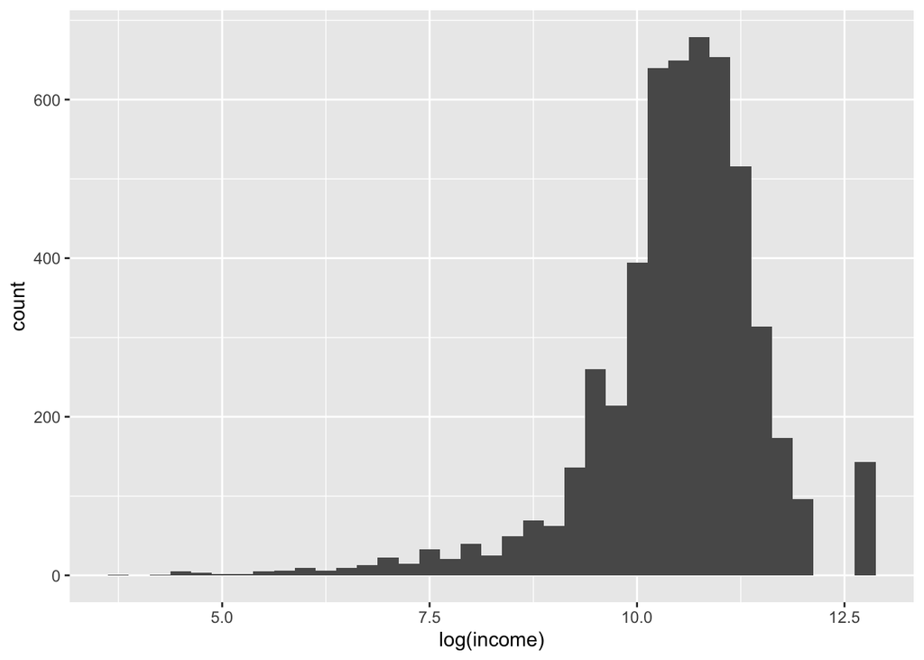

```r
wages %>%
 ggplot(aes(log(income))) + geom_histogram(binwidth = 0.25)
```

## Your Turn 2

Use a pipe to model `log(income)` against `height`. Then use broom and dplyr functions to extract:

1. The **coefficient estimates** and their related statistics
2. The **adj.r.squared** and **p.value** for the overall model

```r
mod_e <-lm(log(income) ~ education, data = wages)
view(mod_e)
class(mod_e)
```

```
## [1] "lm"
```

```r
summary(mod_e) # give you all model parameters
```

```
##
## Call:
## lm(formula = log(income) ~ education, data = wages)
##
## Residuals:
##     Min      1Q  Median      3Q     Max
## -6.7893 -0.3563  0.1328  0.5798  2.9136
##
## Coefficients:
##             Estimate Std. Error t value Pr(>|t|)
## (Intercept) 8.557691   0.073260  116.81   <2e-16 ***
## education   0.141840   0.005305   26.74   <2e-16 ***
## ---
## Signif. codes:  0 '***' 0.001 '**' 0.01 '*' 0.05 '.' 0.1 ' ' 1
##
## Residual standard error: 0.9923 on 5262 degrees of freedom
##   (2 observations deleted due to missingness)
## Multiple R-squared:  0.1196, Adjusted R-squared:  0.1195
## F-statistic:   715 on 1 and 5262 DF,  p-value: < 2.2e-16
```

```r
# can pass the data using a dot for data = .

mod_e <- wages %>%
 lm(log(income) ~ education, data = .)
summary(mod_e)
```

```
##
## Call:
## lm(formula = log(income) ~ education, data = .)
##
## Residuals:
##     Min      1Q  Median      3Q     Max
## -6.7893 -0.3563  0.1328  0.5798  2.9136
##
## Coefficients:
##             Estimate Std. Error t value Pr(>|t|)
## (Intercept) 8.557691   0.073260  116.81   <2e-16 ***
## education   0.141840   0.005305   26.74   <2e-16 ***
## ---
## Signif. codes:  0 '***' 0.001 '**' 0.01 '*' 0.05 '.' 0.1 ' ' 1
##
## Residual standard error: 0.9923 on 5262 degrees of freedom
##   (2 observations deleted due to missingness)
## Multiple R-squared:  0.1196, Adjusted R-squared:  0.1195
## F-statistic:   715 on 1 and 5262 DF,  p-value: < 2.2e-16
```

```r
mod_e %>% tidy() # now this is a tibble and you can reach in and grab the estimates
```

```
## # A tibble: 2 x 5
##   term        estimate std.error statistic   p.value
##   <chr>          <dbl>     <dbl>     <dbl>     <dbl>
## 1 (Intercept)    8.56    0.0733      117.  0.
## 2 education      0.142   0.00530      26.7 8.41e-148
```

```r
mod_e %>% glance()
```

```
## # A tibble: 1 x 11
##   r.squared adj.r.squared sigma statistic   p.value    df logLik    AIC
##       <dbl>         <dbl> <dbl>     <dbl>     <dbl> <int>  <dbl>  <dbl>
## 1     0.120         0.119 0.992      715. 8.41e-148     2 -7428. 14862.
## # … with 3 more variables: BIC <dbl>, deviance <dbl>, df.residual <int>
```

```r
mod_e %>% augment()
```

```
## # A tibble: 5,264 x 10
##    .rownames log.income. education .fitted .se.fit  .resid    .hat .sigma
##    <chr>           <dbl>     <int>   <dbl>   <dbl>   <dbl>   <dbl>  <dbl>
##  1 1                9.85        13   10.4   0.0140 -0.549  1.99e-4  0.992
##  2 2               10.5         10    9.98  0.0234  0.487  5.54e-4  0.992
##  3 3               11.6         16   10.8   0.0188  0.735  3.59e-4  0.992
##  4 4               10.6         14   10.5   0.0139  0.0532 1.95e-4  0.992
##  5 5               11.2         14   10.5   0.0139  0.682  1.95e-4  0.992
##  6 6               11.5         18   11.1   0.0272  0.422  7.51e-4  0.992
##  7 7               11.2         12   10.3   0.0160  0.896  2.60e-4  0.992
##  8 8               11.0         12   10.3   0.0160  0.742  2.60e-4  0.992
##  9 9               11.9         13   10.4   0.0140  1.52   1.99e-4  0.992
## 10 10              11.7         16   10.8   0.0188  0.826  3.59e-4  0.992
## # … with 5,254 more rows, and 2 more variables: .cooksd <dbl>,
## #   .std.resid <dbl>
```

```r
mod_e %>% augment(data = wages)
```

```
## # A tibble: 5,264 x 15
##    income height weight   age marital sex   education  afqt .fitted .se.fit
##     <int>  <dbl>  <int> <int> <fct>   <fct>     <int> <dbl>   <dbl>   <dbl>
##  1  19000     60    155    53 married fema…        13  6.84   10.4   0.0140
##  2  35000     70    156    51 married fema…        10 49.4     9.98  0.0234
##  3 105000     65    195    52 married male         16 99.4    10.8   0.0188
##  4  40000     63    197    54 married fema…        14 44.0    10.5   0.0139
##  5  75000     66    190    49 married male         14 59.7    10.5   0.0139
##  6 102000     68    200    49 divorc… fema…        18 98.8    11.1   0.0272
##  7  70000     64    160    54 divorc… fema…        12 50.3    10.3   0.0160
##  8  60000     69    162    55 divorc… male         12 89.7    10.3   0.0160
##  9 150000     69    194    54 divorc… male         13 96.0    10.4   0.0140
## 10 115000     64    145    53 married fema…        16 67.0    10.8   0.0188
## # … with 5,254 more rows, and 5 more variables: .resid <dbl>, .hat <dbl>,
## #   .sigma <dbl>, .cooksd <dbl>, .std.resid <dbl>
```

```r
mod_h <- wages %>%
  lm(log(income) ~ height, data = .)

estimates <- mod_h %>% tidy()
str(estimates)
```

```
## Classes 'tbl_df', 'tbl' and 'data.frame':    2 obs. of  5 variables:
##  $ term     : chr  "(Intercept)" "height"
##  $ estimate : num  6.983 0.052
##  $ std.error: num  0.23748 0.00352
##  $ statistic: num  29.4 14.8
##  $ p.value  : num  4.13e-176 2.44e-48
```

```r
fit <- mod_h %>% glance()
fit1 <- mod_h %>% glance() %>% select(adj.r.squared, p.value)
str(fit)
```

```
## Classes 'tbl_df', 'tbl' and 'data.frame':    1 obs. of  11 variables:
##  $ r.squared    : num 0.0397
##  $ adj.r.squared: num 0.0396
##  $ sigma        : num 1.04
##  $ statistic    : num 218
##  $ p.value      : num 2.44e-48
##  $ df           : int 2
##  $ logLik       : num -7659
##  $ AIC          : num 15324
##  $ BIC          : num 15343
##  $ deviance     : num 5653
##  $ df.residual  : int 5264
```

```r
aug <- mod_h %>% augment()
str(aug)
```

```
## Classes 'tbl_df', 'tbl' and 'data.frame':    5266 obs. of  9 variables:
##  $ log.income.: num  9.85 10.46 11.56 10.6 11.23 ...
##  $ height     : num  60 70 65 63 66 68 64 69 69 64 ...
##  $ .fitted    : num  10.1 10.6 10.4 10.3 10.4 ...
##  $ .se.fit    : num  0.0294 0.0171 0.0164 0.0208 0.015 ...
##  $ .resid     : num  -0.25 -0.159 1.2 0.339 0.811 ...
##  $ .hat       : num  0.000808 0.000273 0.000252 0.000405 0.00021 ...
##  $ .sigma     : num  1.04 1.04 1.04 1.04 1.04 ...
##  $ .cooksd    : num  2.35e-05 3.21e-06 1.69e-04 2.16e-05 6.43e-05 ...
##  $ .std.resid : num  -0.241 -0.153 1.158 0.327 0.783 ...
```

## Your Turn 3

Model `log(income)` against `education` *and* `height`. Do the coefficients change?

```r
mod_eh <- wages %>% lm(log(income) ~ education + height, data = .)
summary(mod_eh)
```

```
##
## Call:
## lm(formula = log(income) ~ education + height, data = .)
##
## Residuals:
##     Min      1Q  Median      3Q     Max
## -6.8991 -0.3477  0.1544  0.5579  3.0110
##
## Coefficients:
##             Estimate Std. Error t value Pr(>|t|)
## (Intercept) 5.348376   0.231320   23.12   <2e-16 ***
## education   0.138713   0.005205   26.65   <2e-16 ***
## height      0.048309   0.003310   14.60   <2e-16 ***
## ---
## Signif. codes:  0 '***' 0.001 '**' 0.01 '*' 0.05 '.' 0.1 ' ' 1
##
## Residual standard error: 0.9729 on 5261 degrees of freedom
##   (2 observations deleted due to missingness)
## Multiple R-squared:  0.1539, Adjusted R-squared:  0.1536
## F-statistic: 478.4 on 2 and 5261 DF,  p-value: < 2.2e-16
```

```r
mod_eh %>%
  tidy()
```

```
## # A tibble: 3 x 5
##   term        estimate std.error statistic   p.value
##   <chr>          <dbl>     <dbl>     <dbl>     <dbl>
## 1 (Intercept)   5.35     0.231        23.1 1.00e-112
## 2 education     0.139    0.00521      26.6 7.12e-147
## 3 height        0.0483   0.00331      14.6 2.50e- 47
```

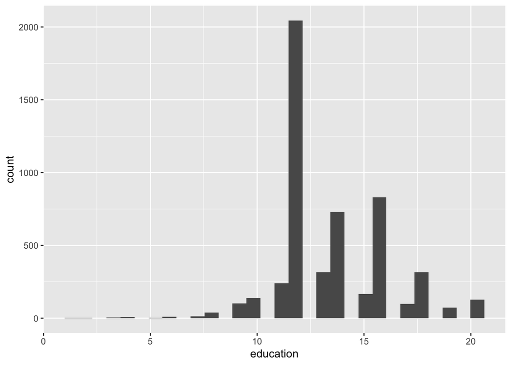

```r
wages %>%
  ggplot() + geom_histogram(aes(x = education, binwidth = 0.25))
```

## Your Turn 4

Model `log(income)` against `education` and `height` and `sex`. Can you interpret the coefficients?

```r
mod_ehs <- wages %>%
 lm(log(income) ~ education + height + sex, data = .)
mod_ehs %>%
  tidy()
```

```
## # A tibble: 4 x 5
##   term        estimate std.error statistic   p.value
##   <chr>          <dbl>     <dbl>     <dbl>     <dbl>
## 1 (Intercept)  8.25      0.335       24.6  4.68e-127
## 2 education    0.148     0.00520     28.5  5.16e-166
## 3 height       0.00673   0.00479      1.40 1.61e-  1
## 4 sexfemale   -0.462     0.0389     -11.9  5.02e- 32
```

## Your Turn 5

Use a broom function and ggplot2 to make a line graph of `height` vs `.fitted` for our heights model, `mod_h`.

*Bonus: Overlay the plot on the original data points.*

```r
mod_h <- wages %>% lm(log(income) ~ height, data = .)
mod_h %>% tidy()
```

```
## # A tibble: 2 x 5
##   term        estimate std.error statistic   p.value
##   <chr>          <dbl>     <dbl>     <dbl>     <dbl>
## 1 (Intercept)   6.98     0.237        29.4 4.13e-176
## 2 height        0.0520   0.00352      14.8 2.44e- 48
```

```r
mod_h %>% glance()
```

```
## # A tibble: 1 x 11
##   r.squared adj.r.squared sigma statistic  p.value    df logLik    AIC
##       <dbl>         <dbl> <dbl>     <dbl>    <dbl> <int>  <dbl>  <dbl>
## 1    0.0397        0.0396  1.04      218. 2.44e-48     2 -7659. 15324.
## # … with 3 more variables: BIC <dbl>, deviance <dbl>, df.residual <int>
```

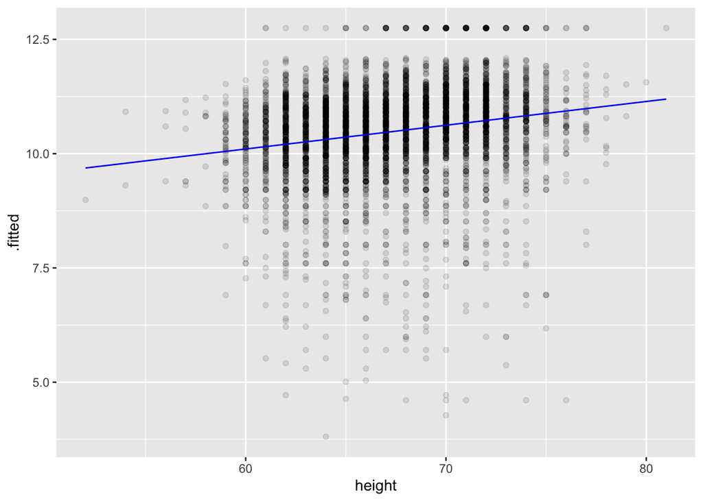

```r
height1 <- mod_h %>% augment()

mod_h %>%
 augment(data = wages) %>%
 ggplot(mapping = aes(x = height, y = .fitted)) +
 geom_point(mapping = aes(y = log(income)), alpha = 0.1) +
 geom_line(color = "blue")
```

## Your Turn 6

Repeat the process to make a line graph of `height` vs `.fitted` colored by `sex` for model `mod_ehs`. Are the results interpretable? Add `+ facet_wrap(~education)` to the end of your code. What happens?

```
## geom_path: Each group consists of only one observation. Do you need to
## adjust the group aesthetic?
## geom_path: Each group consists of only one observation. Do you need to
## adjust the group aesthetic?
```

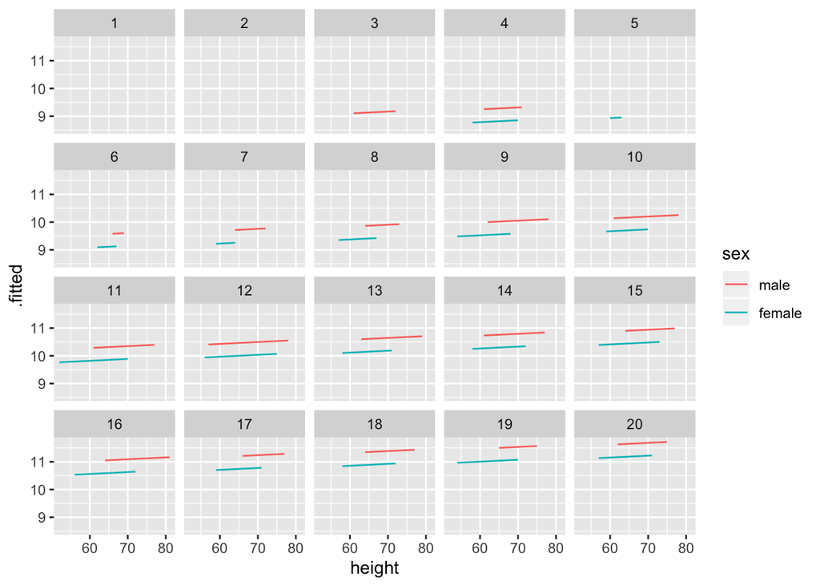

```r
mod_ehs <- wages %>% lm(log(income) ~ education + height + sex, data = .)

mod_ehs %>%
 augment(data = wages) %>%
 ggplot(mapping = aes(x = height, y = .fitted, color = sex)) +
 geom_line() +
 facet_wrap(~ education)
```

## Your Turn 7

Use one of `spread_predictions()` or `gather_predictions()` to make a line graph of `height` vs `pred` colored by `model` for each of mod_h, mod_eh, and mod_ehs. Are the results interpretable?

Add `+ facet_grid(sex ~ education)` to the end of your code. What happens?

```r
mod_h <- wages %>% lm(log(income) ~ height, data = .)
mod_eh <- wages %>% lm(log(income) ~ education + height, data = .)
mod_ehs <- wages %>% lm(log(income) ~ education + height + sex, data = .)

wages %>%
 spread_predictions(mod_h, mod_eh, mod_ehs)
```

```
## # A tibble: 5,266 x 11
##    income height weight   age marital sex   education  afqt mod_h mod_eh
##     <int>  <dbl>  <int> <int> <fct>   <fct>     <int> <dbl> <dbl>  <dbl>
##  1  19000     60    155    53 married fema…        13  6.84  10.1   10.1
##  2  35000     70    156    51 married fema…        10 49.4   10.6   10.1
##  3 105000     65    195    52 married male         16 99.4   10.4   10.7
##  4  40000     63    197    54 married fema…        14 44.0   10.3   10.3
##  5  75000     66    190    49 married male         14 59.7   10.4   10.5
##  6 102000     68    200    49 divorc… fema…        18 98.8   10.5   11.1
##  7  70000     64    160    54 divorc… fema…        12 50.3   10.3   10.1
##  8  60000     69    162    55 divorc… male         12 89.7   10.6   10.3
##  9 150000     69    194    54 divorc… male         13 96.0   10.6   10.5
## 10 115000     64    145    53 married fema…        16 67.0   10.3   10.7
## # … with 5,256 more rows, and 1 more variable: mod_ehs <dbl>
```

```r
wages %>%
 gather_predictions(mod_h, mod_eh, mod_ehs)
```

```
## # A tibble: 15,798 x 10
##    model income height weight   age marital  sex    education  afqt  pred
##    <chr>  <int>  <dbl>  <int> <int> <fct>    <fct>      <int> <dbl> <dbl>
##  1 mod_h  19000     60    155    53 married  female        13  6.84  10.1
##  2 mod_h  35000     70    156    51 married  female        10 49.4   10.6
##  3 mod_h 105000     65    195    52 married  male          16 99.4   10.4
##  4 mod_h  40000     63    197    54 married  female        14 44.0   10.3
##  5 mod_h  75000     66    190    49 married  male          14 59.7   10.4
##  6 mod_h 102000     68    200    49 divorced female        18 98.8   10.5
##  7 mod_h  70000     64    160    54 divorced female        12 50.3   10.3
##  8 mod_h  60000     69    162    55 divorced male          12 89.7   10.6
##  9 mod_h 150000     69    194    54 divorced male          13 96.0   10.6
## 10 mod_h 115000     64    145    53 married  female        16 67.0   10.3
## # … with 15,788 more rows
```

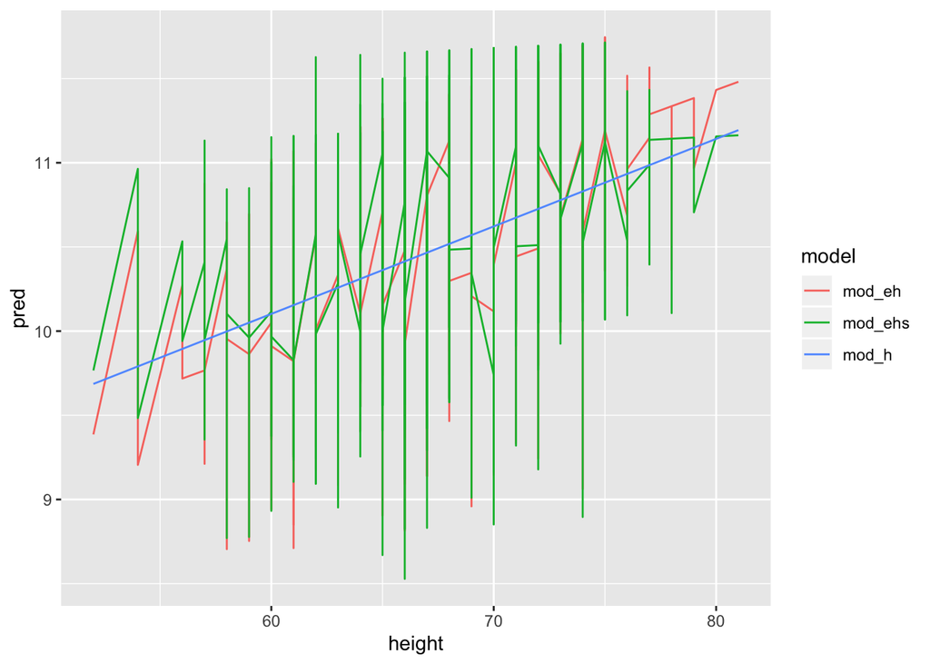

```r
wages %>%
 gather_predictions(mod_h, mod_eh, mod_ehs) %>%
 ggplot(mapping = aes(x = height, y = pred, color = model)) +
 geom_line()
```

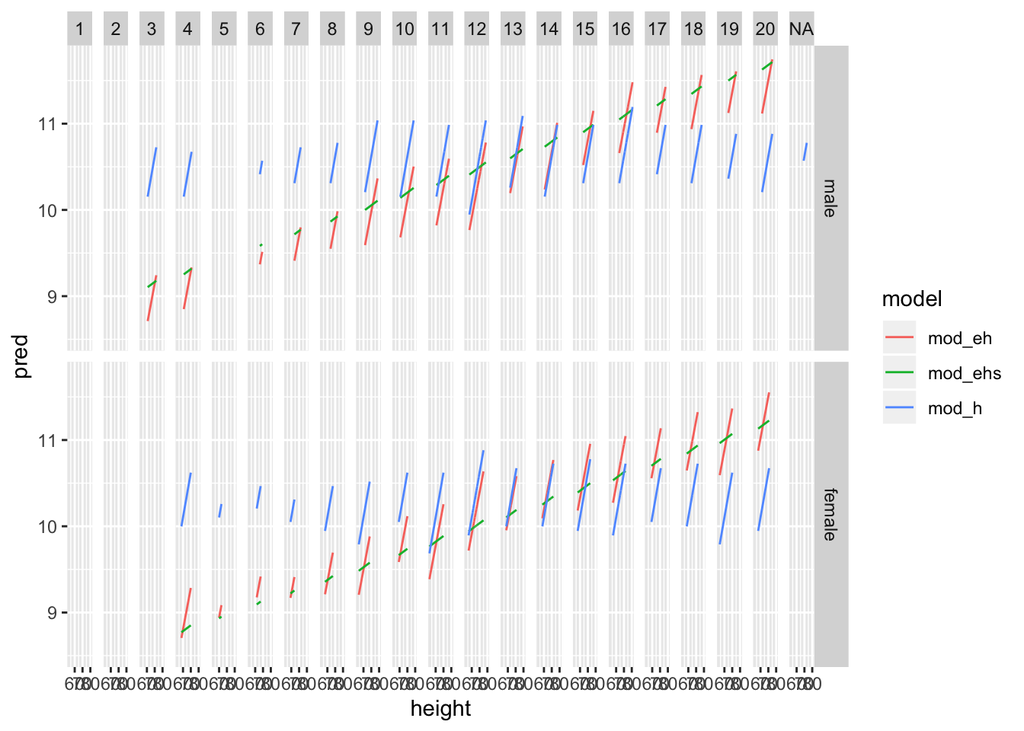

```r
wages %>%
 gather_predictions(mod_h, mod_eh, mod_ehs) %>%
 ggplot(mapping = aes(x = height, y = pred, color = model)) +
 geom_line() +
 facet_grid(sex ~ education)
```

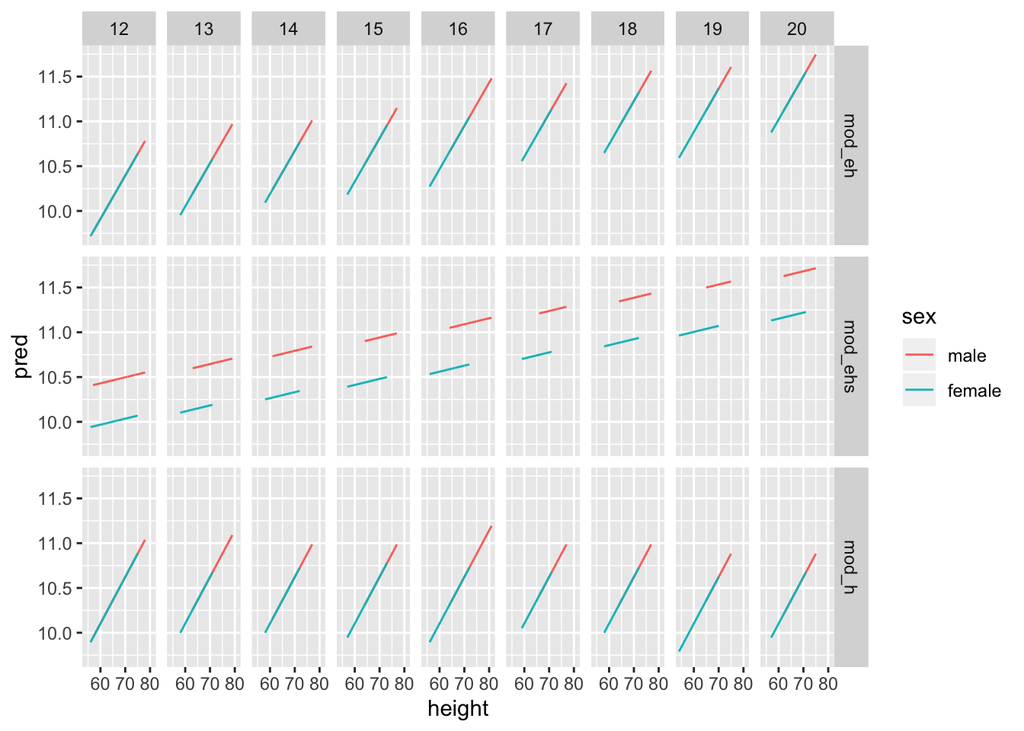

```r
wages %>%
 gather_predictions(mod_h, mod_eh, mod_ehs) %>%
 filter(education > 11) %>%
 ggplot(mapping = aes(x = height, y = pred, color = sex)) +
 geom_line() +
 facet_grid(model ~ education)
```

# Take Aways

- Use `glance()`, `tidy()`, and `augment()` from the **broom** package to return model values in a data frame.
- Use `add_predictions()` or `gather_predictions()` or `spread_predictions()` from the **modelr** package to visualize predictions.
- Use `add_residuals()` or `gather_residuals()` or `spread_residuals()` from the **modelr** package to visualize residuals.